#### Problem 3

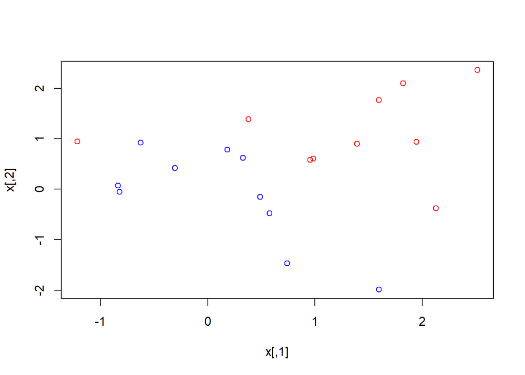

```r
library(e1071)
set.seed (1)
x=matrix (rnorm (20*2) , ncol =2)
y=c(rep (-1,10) , rep (1 ,10) )
x[y==1 ,] = x[y==1,] + 1
plot(x, col =(3-y))
```

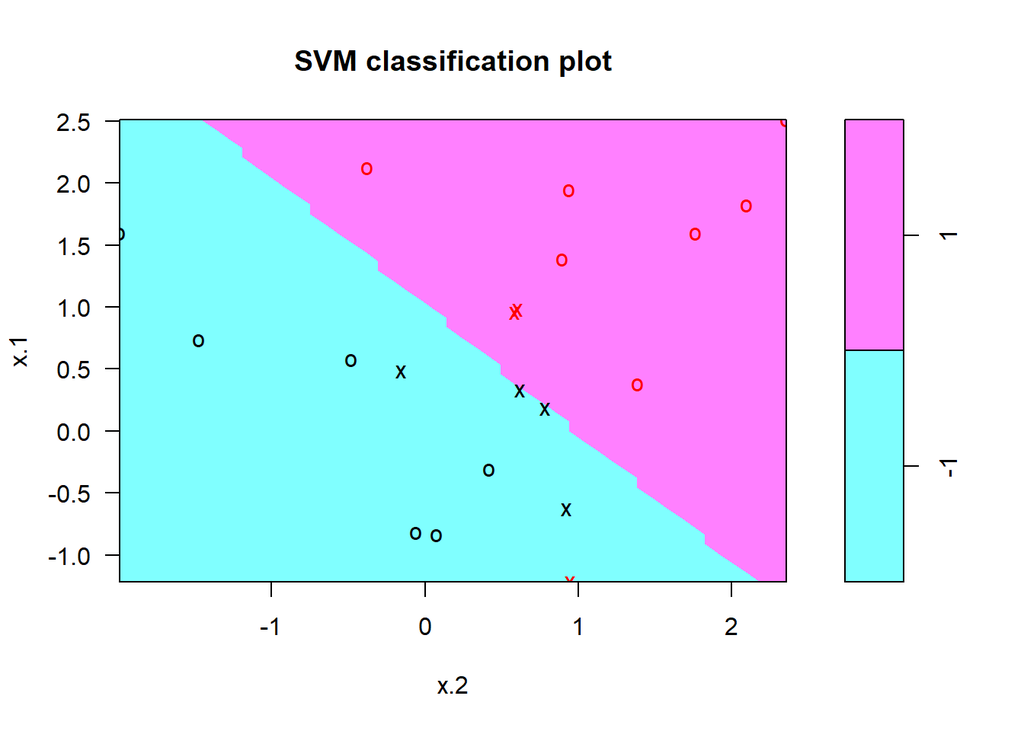

```r
dat=data.frame(x=x, y=as.factor(y))
library (e1071)
svmfit =svm(y~., data=dat , kernel ="linear", cost =10, scale =FALSE )
plot(svmfit , dat)
```

```r
svmfit$index
```

```
## [1]  1  2  5  7 14 16 17
```

```r
summary (svmfit )
```

```
##
## Call:
## svm(formula = y ~ ., data = dat, kernel = "linear", cost = 10,
##     scale = FALSE)
##
##
## Parameters:
##    SVM-Type:  C-classification
##  SVM-Kernel:  linear
##        cost:  10
##       gamma:  0.5
##
## Number of Support Vectors:  7
##
##  ( 4 3 )
##
##
## Number of Classes:  2
##
## Levels:
##  -1 1
```

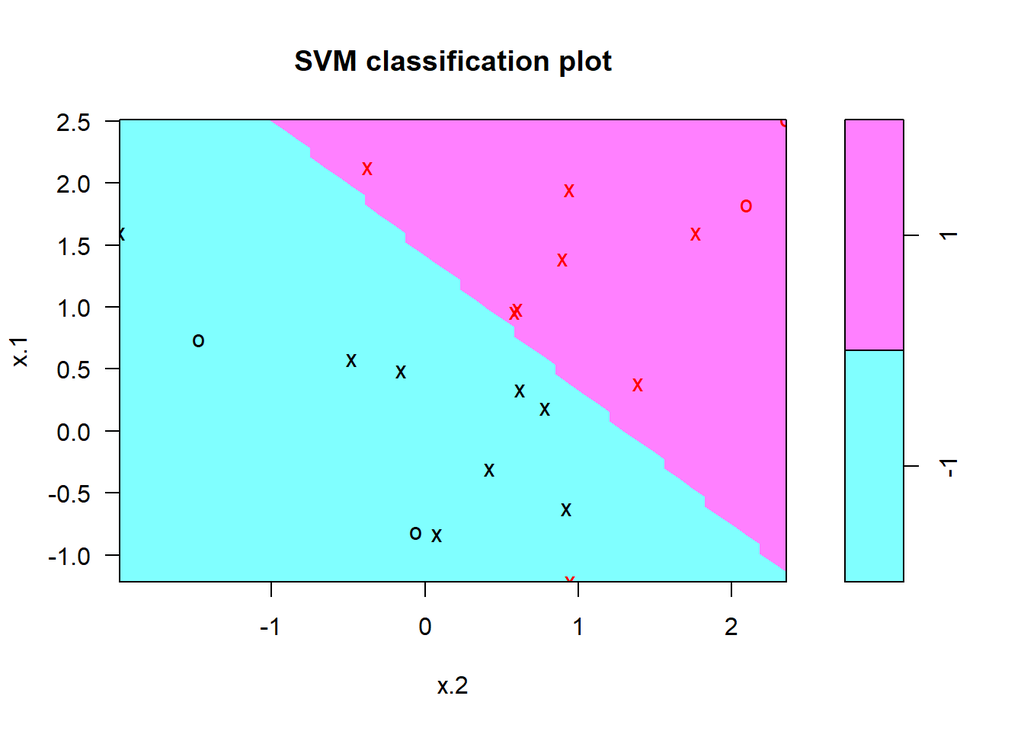

```r
svmfit =svm(y~., data=dat , kernel ="linear", cost =0.1, scale =FALSE )
plot(svmfit , dat)
```

```r
svmfit$index
```

```
##  [1]  1  2  3  4  5  7  9 10 12 13 14 15 16 17 18 20
```

```r
set.seed (1)
tune.out=tune(svm ,y~.,data=dat,kernel ="linear",ranges =list(cost=c(0.001 , 0.01, 0.1, 1,5,10,100)))
summary(tune.out)
```

```
##
## Parameter tuning of 'svm':
##
## - sampling method: 10-fold cross validation
##
## - best parameters:
##  cost
##   0.1
##
## - best performance: 0.1
##
## - Detailed performance results:
##    cost error dispersion
## 1 1e-03  0.70  0.4216370
## 2 1e-02  0.70  0.4216370
## 3 1e-01  0.10  0.2108185
## 4 1e+00  0.15  0.2415229
## 5 5e+00  0.15  0.2415229
## 6 1e+01  0.15  0.2415229
## 7 1e+02  0.15  0.2415229
```

```r
bestmod = tune.out$best.model
summary(bestmod)
```

```
##
## Call:
## best.tune(method = svm, train.x = y ~ ., data = dat, ranges = list(cost = c(0.001,
##     0.01, 0.1, 1, 5, 10, 100)), kernel = "linear")
##
##
## Parameters:
##    SVM-Type:  C-classification
##  SVM-Kernel:  linear
##        cost:  0.1
##       gamma:  0.5
##
## Number of Support Vectors:  16
##
##  ( 8 8 )
##
##
## Number of Classes:  2
##
## Levels:
##  -1 1
```

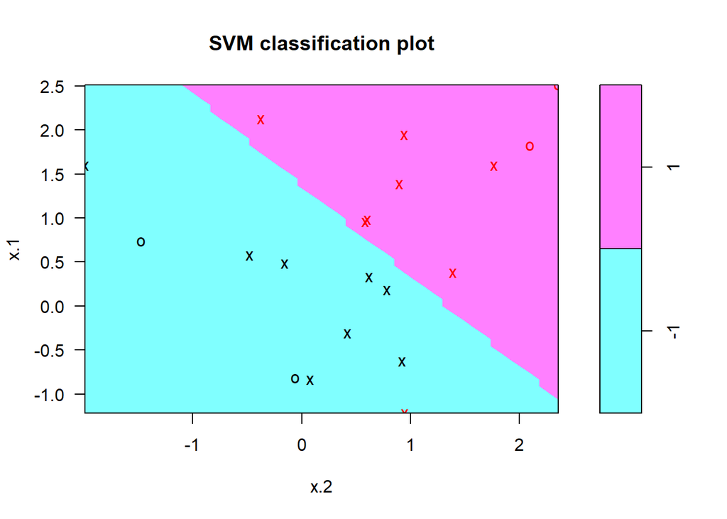

```r
plot(bestmod,dat)
```

```r
xtest=matrix (rnorm (20*2) , ncol =2)
ytest=sample (c(-1,1) , 20, rep=TRUE)
xtest[ytest ==1 ,]= xtest[ytest ==1,] + 1
testdat =data.frame (x = xtest , y=as.factor(ytest))
```

```r
#for some mysterious reason the predict just won't return value, only null
#but the predicted y can be seen in html output -->
(ypred = predict(bestmod,testdat))
```

```
##  1  2  3  4  5  6  7  8  9 10 11 12 13 14 15 16 17 18 19 20
##  1 -1 -1 -1  1 -1 -1 -1  1  1  1  1 -1 -1 -1 -1  1 -1 -1  1
## Levels: -1 1
```

```r
(ypred2 = predict(svmfit,testdat))
```

```
##  1  2  3  4  5  6  7  8  9 10 11 12 13 14 15 16 17 18 19 20
##  1 -1 -1 -1  1 -1 -1 -1  1  1  1  1 -1 -1 -1 -1  1 -1 -1  1
## Levels: -1 1
```

```r
ypred <- c( -1, -1, -1, -1, -1, -1, -1, -1, -1, -1,  1,  1,  1, -1,  1,  1,  1,  1,  1,  1)
table(predict =ypred , truth= testdat$y )
```

```
##        truth
## predict -1 1
##      -1  6 5
##      1   5 4
```

```r
svmfit10 =svm(y~., data=dat , kernel ="linear", cost = 10, scale =FALSE )
(ypred10 = predict(svmfit,testdat))
```

```
##  1  2  3  4  5  6  7  8  9 10 11 12 13 14 15 16 17 18 19 20
##  1 -1 -1 -1  1 -1 -1 -1  1  1  1  1 -1 -1 -1 -1  1 -1 -1  1
## Levels: -1 1
```

```r
#table(predict =ypred , truth= testdat$y )
#table(predict =ypred2 , truth= testdat$y )
#table(predict =ypred10 , truth= testdat$y )
```

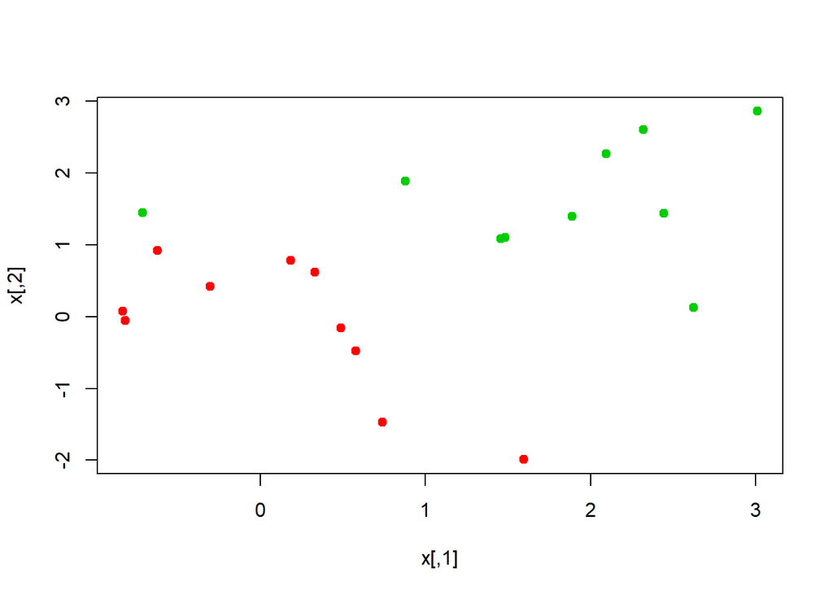

```r
x[y==1 ,]= x[y==1 ,]+0.5
plot(x, col =(y+5) /2, pch =19)
```

```r
dat=data.frame(x=x,y=as.factor (y))
svmfit =svm(y~., data=dat , kernel ="linear", cost =1e5)
summary (svmfit)
```

```
##
## Call:
## svm(formula = y ~ ., data = dat, kernel = "linear", cost = 1e+05)
##
##
## Parameters:
##    SVM-Type:  C-classification
##  SVM-Kernel:  linear
##        cost:  1e+05
##       gamma:  0.5
##
## Number of Support Vectors:  3
##
##  ( 1 2 )
##
##
## Number of Classes:  2
##
## Levels:
##  -1 1
```

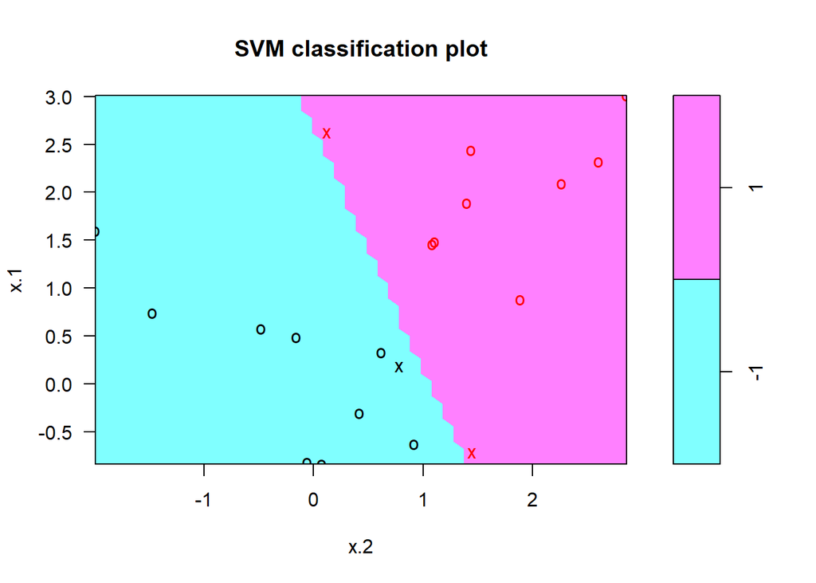

```r
plot(svmfit , dat)
```

```r
svmfit =svm(y~., data=dat , kernel ="linear", cost =1)
summary (svmfit)
```

```
##
## Call:
## svm(formula = y ~ ., data = dat, kernel = "linear", cost = 1)
##
##
## Parameters:
##    SVM-Type:  C-classification
##  SVM-Kernel:  linear
##        cost:  1
##       gamma:  0.5
##
## Number of Support Vectors:  7
##
##  ( 4 3 )
##
##
## Number of Classes:  2
##
## Levels:
##  -1 1
```

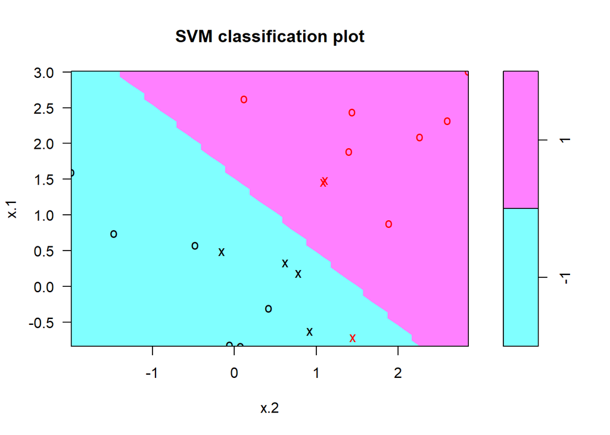

```r
plot(svmfit , dat)
```

### Task 3/3 a

```r
probYplus1 <- function(x1,x2)
{
  px1 = 1/16*exp(-(x1^2+x2^2)/32)
  px2 = exp(-(x1^2+x2^2)/2)
  return(px1/(px1+px2))
}
probYminus1 <- function(x1,x2)
{
  px1 = 1/16*exp(-(x1^2+x2^2)/32)
  px2 = exp(-(x1^2+x2^2)/2)
  return(px2/(px1+px2))
}
```

```r
library(MASS)
corr = c(1, 0, 0, 16)
sigma <- matrix(corr,nrow=2, ncol=2)
sample <- mvrnorm(200,c(0,0), Sigma = sigma)
sampley <- runif(200, min = 0, max = 1)
sampley <- probYplus1(sample[,1],sample[,2])>=sampley
smp <- data.frame(x = sample, y = as.factor(sampley))
head(smp)
```

```
##          x.1        x.2     y
## 1 -0.9510128  9.6064710  TRUE
## 2  0.3892372 -0.1569600 FALSE
## 3  0.2843307  2.7589574 FALSE
## 4 -0.8574098  0.1120086  TRUE
## 5 -1.7196273 -2.9730928  TRUE
## 6 -0.2700549  0.7551692 FALSE
```

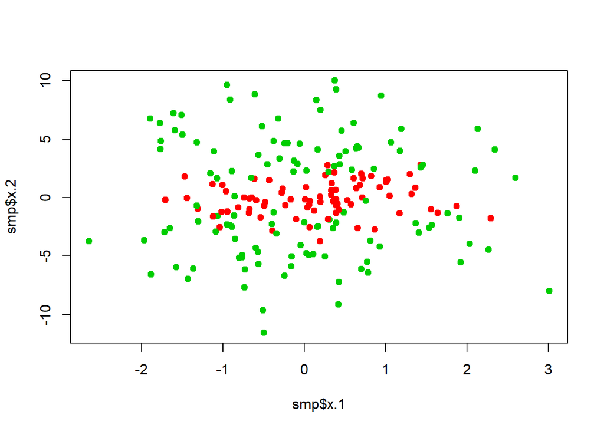

```r
#plot(x, col =(y+5) /2, pch =19)
plot(smp$x.1,smp$x.2,col = (sampley + 5)/2, pch = 19)
```

```r
set.seed (1)
tune.out=tune(svm ,y~.,data=smp,kernel ="linear",ranges =list(cost=c(0.001 , 0.01, 0.1, 1,5,10,100)))
summary(tune.out)
```

```
##
## Parameter tuning of 'svm':
##
## - sampling method: 10-fold cross validation
##
## - best parameters:
##   cost
##  0.001
##
## - best performance: 0.395
##
## - Detailed performance results:
##    cost error dispersion
## 1 1e-03 0.395 0.04972145
## 2 1e-02 0.395 0.04972145
## 3 1e-01 0.395 0.04972145
## 4 1e+00 0.395 0.04972145
## 5 5e+00 0.395 0.04972145
## 6 1e+01 0.395 0.04972145
## 7 1e+02 0.395 0.04972145
```

```r
bestmod = tune.out$best.model
summary(bestmod)
```

```
##
## Call:
## best.tune(method = svm, train.x = y ~ ., data = smp, ranges = list(cost = c(0.001,
##     0.01, 0.1, 1, 5, 10, 100)), kernel = "linear")
##
##
## Parameters:
##    SVM-Type:  C-classification
##  SVM-Kernel:  linear
##        cost:  0.001
##       gamma:  0.5
##
## Number of Support Vectors:  159
##
##  ( 80 79 )
##
##
## Number of Classes:  2
##
## Levels:
##  FALSE TRUE
```

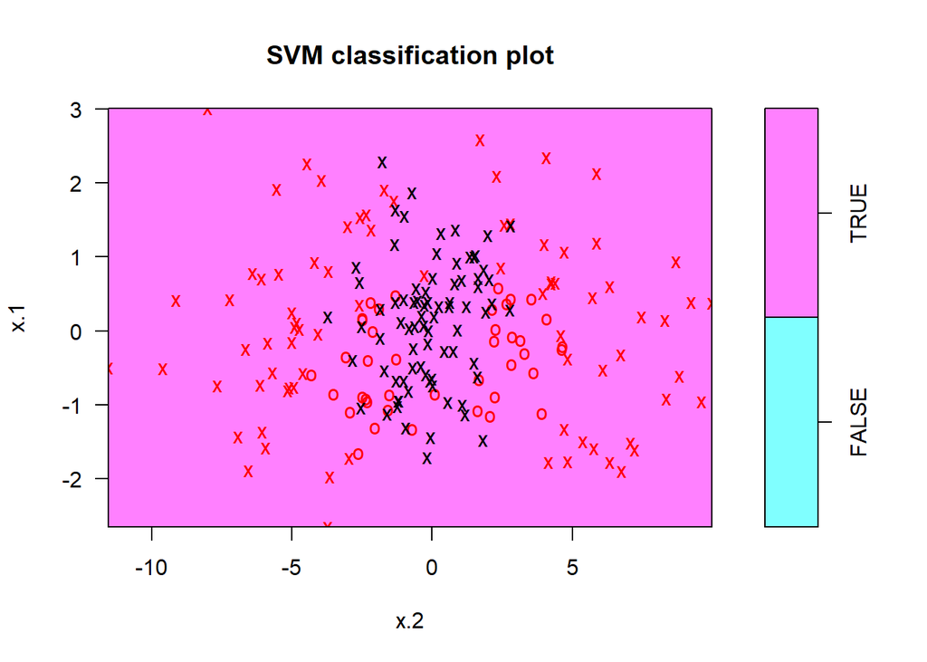

```r
plot(bestmod,smp)
```

```r
#dat=data.frame(x=x,y=as.factor (y))
#svmfit =svm(y~., data=dat , kernel ="linear", cost =1e5)
#summary (svmfit)
#plot(svmfit , dat)
```

```r
set.seed (1)
tune.out=tune(svm ,y~.,data=smp,kernel ="polynomial",degree=2, ranges =list(cost=c(0.001 , 0.01, 0.1, 1,5,10,100, 150)))
summary(tune.out)
```

```
##
## Parameter tuning of 'svm':
##
## - sampling method: 10-fold cross validation
##
## - best parameters:
##  cost
##   100
##
## - best performance: 0.14
##
## - Detailed performance results:
##      cost error dispersion
## 1   0.001 0.395 0.04972145
## 2   0.010 0.395 0.04972145
## 3   0.100 0.225 0.10341395
## 4   1.000 0.215 0.08834906
## 5   5.000 0.180 0.06749486
## 6  10.000 0.155 0.07975657
## 7 100.000 0.140 0.08096639
## 8 150.000 0.140 0.08096639
```

```r
bestmod = tune.out$best.model
summary(bestmod)
```

```
##
## Call:
## best.tune(method = svm, train.x = y ~ ., data = smp, ranges = list(cost = c(0.001,
##     0.01, 0.1, 1, 5, 10, 100, 150)), kernel = "polynomial", degree = 2)
##
##
## Parameters:
##    SVM-Type:  C-classification
##  SVM-Kernel:  polynomial
##        cost:  100
##      degree:  2
##       gamma:  0.5
##      coef.0:  0
##
## Number of Support Vectors:  68
##
##  ( 34 34 )
##
##
## Number of Classes:  2
##
## Levels:
##  FALSE TRUE
```

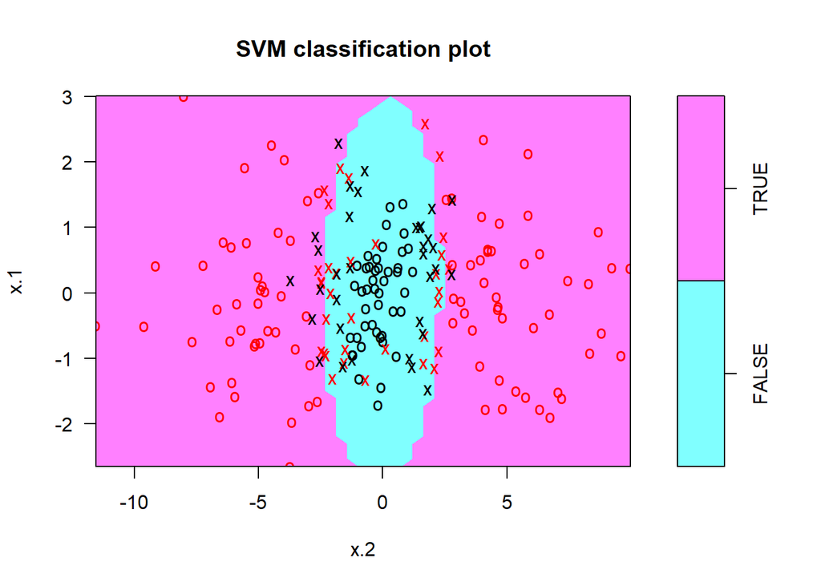

```r
plot(bestmod,smp)
```

```r
set.seed (1)
tune.out=tune(svm ,y~.,data=smp,kernel ="radial", ranges =list(cost=c(0.001 , 0.01, 0.1, 1,5,10,100, 150)))
summary(tune.out)
```

```
##
## Parameter tuning of 'svm':
##
## - sampling method: 10-fold cross validation
##
## - best parameters:
##  cost
##   100
##
## - best performance: 0.16
##
## - Detailed performance results:
##      cost error dispersion
## 1   0.001 0.395 0.04972145
## 2   0.010 0.395 0.04972145
## 3   0.100 0.195 0.05986095
## 4   1.000 0.180 0.09486833
## 5   5.000 0.165 0.07835106
## 6  10.000 0.175 0.08897565
## 7 100.000 0.160 0.07745967
## 8 150.000 0.165 0.07472171
```

```r
bestmod = tune.out$best.model
summary(bestmod)
```

```
##
## Call:
## best.tune(method = svm, train.x = y ~ ., data = smp, ranges = list(cost = c(0.001,
##     0.01, 0.1, 1, 5, 10, 100, 150)), kernel = "radial")
##
##
## Parameters:
##    SVM-Type:  C-classification
##  SVM-Kernel:  radial
##        cost:  100
##       gamma:  0.5
##
## Number of Support Vectors:  69
##
##  ( 36 33 )
##
##
## Number of Classes:  2
##
## Levels:
##  FALSE TRUE
```

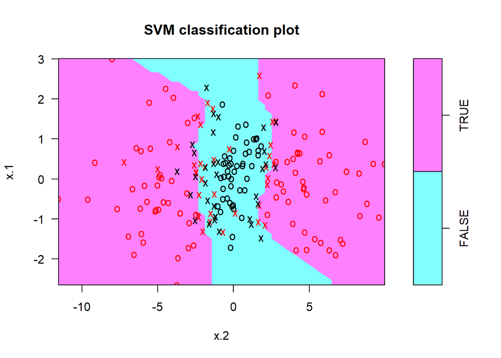

```r
plot(bestmod,smp)
```

Now, modify the data by adding two more variables as x^2 for both x’s:

Try first the linear kernel:

```r
library(plyr)
smp <- mutate(smp, x.3 = x.1^2, x.4 = x.2^2)
set.seed (1)
tune.out=tune(svm ,y~.,data=smp,kernel ="linear",ranges =list(cost=c(0.001 , 0.01, 0.1, 1,5,10,100, 150)))
summary(tune.out)
```

```
##
## Parameter tuning of 'svm':
##
## - sampling method: 10-fold cross validation
##
## - best parameters:
##  cost
##   100
##
## - best performance: 0.125
##
## - Detailed performance results:
##      cost error dispersion
## 1   0.001 0.395 0.04972145
## 2   0.010 0.395 0.04972145
## 3   0.100 0.235 0.10013879
## 4   1.000 0.190 0.07378648
## 5   5.000 0.145 0.07245688
## 6  10.000 0.135 0.07472171
## 7 100.000 0.125 0.07546154
## 8 150.000 0.130 0.07888106
```

```r
bestmod = tune.out$best.model
summary(bestmod)
```

```
##
## Call:
## best.tune(method = svm, train.x = y ~ ., data = smp, ranges = list(cost = c(0.001,
##     0.01, 0.1, 1, 5, 10, 100, 150)), kernel = "linear")
##
##
## Parameters:
##    SVM-Type:  C-classification
##  SVM-Kernel:  linear
##        cost:  100
##       gamma:  0.25
##
## Number of Support Vectors:  66
##
##  ( 33 33 )
##
##
## Number of Classes:  2
##
## Levels:
##  FALSE TRUE
```

Now, really, the linear kernel is able to produce error 0.125 with cost level 100. This is because x squared becomes positive for all x AND the results is smaller than x with x < 1 and it bigger if x > 1. For x.1 with mean = 0 & var = 1, it is more likely that x is close to zero AND for x.2 with mean = 0 & var = 16 it is more likely to be more than 1. This is why the model is better able to separate the two sets now as can be seen from the model graph created without the linear x’s.

Drop off the linear x’s, leave only squared x’s and try one more time:

```r
smpSq <- smp
smpSq[,1]= smpSq [,4]
smpSq[,2]= smpSq [,5]
smpSq <- smpSq[-4:-5]
```

```r
head(smpSq)
```

```
##          x.1         x.2     y
## 1 0.90442536 92.28428588  TRUE
## 2 0.15150558  0.02463645 FALSE
## 3 0.08084393  7.61184621 FALSE
## 4 0.73515153  0.01254593  TRUE
## 5 2.95711805  8.83928101  TRUE
## 6 0.07292965  0.57028052 FALSE
```

```r
set.seed (1)
tune.out=tune(svm ,y~.,data=smpSq,kernel ="linear",ranges =list(cost=c(0.001 , 0.01, 0.1, 1,5,10,100, 150)))
summary(tune.out)
```

```
##
## Parameter tuning of 'svm':
##
## - sampling method: 10-fold cross validation
##
## - best parameters:
##  cost
##    10
##
## - best performance: 0.125
##
## - Detailed performance results:
##      cost error dispersion
## 1   0.001 0.395 0.04972145
## 2   0.010 0.395 0.04972145
## 3   0.100 0.210 0.09944289
## 4   1.000 0.195 0.07619420
## 5   5.000 0.140 0.07745967
## 6  10.000 0.125 0.07546154
## 7 100.000 0.135 0.08181958
## 8 150.000 0.135 0.08181958
```

```r
bestmodSq = tune.out$best.model
summary(bestmodSq)
```

```
##
## Call:
## best.tune(method = svm, train.x = y ~ ., data = smpSq, ranges = list(cost = c(0.001,
##     0.01, 0.1, 1, 5, 10, 100, 150)), kernel = "linear")
##
##
## Parameters:
##    SVM-Type:  C-classification
##  SVM-Kernel:  linear
##        cost:  10
##       gamma:  0.5
##
## Number of Support Vectors:  72
##
##  ( 36 36 )
##
##
## Number of Classes:  2
##
## Levels:
##  FALSE TRUE
```

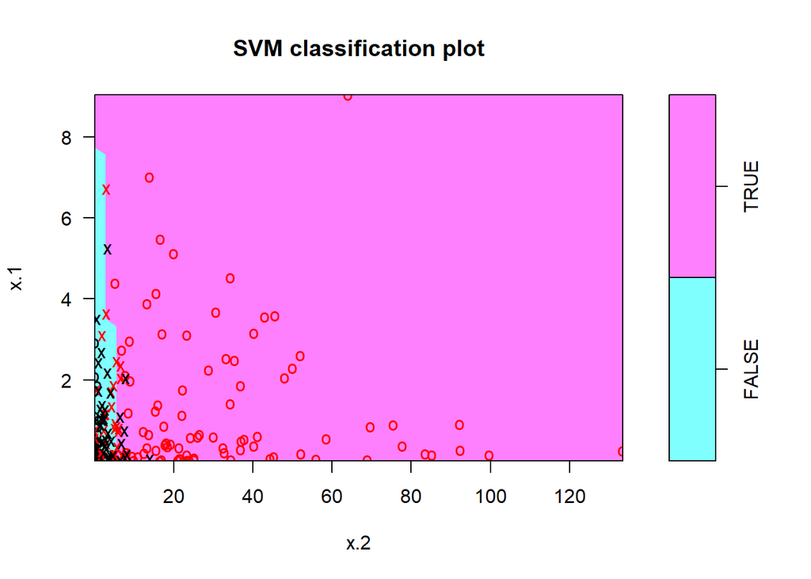

```r
plot(bestmodSq,smpSq)
```

#### Task 3 b

```r
library(ISLR)
data (OJ)
smp_siz = floor(0.8*nrow(OJ))
set.seed(23)   # set seed to ensure you always have same random numbers generated
train_ind = sample(seq_len(nrow(OJ)),size = smp_siz)  # Randomly identifies therows equal to sample size ( defined in previous instruction) from  all the rows of Smarket dataset and stores the row number in train_ind
train =OJ[train_ind,] #creates the training dataset with row numbers stored in train_ind
test=OJ[-train_ind,]
head(train)
```

```
##     Purchase WeekofPurchase StoreID PriceCH PriceMM DiscCH DiscMM
## 617       CH            262       7    1.86    2.13   0.00    0.0
## 239       CH            250       7    1.86    2.09   0.00    0.0
## 355       MM            227       4    1.79    1.79   0.00    0.0
## 759       MM            259       2    1.86    2.18   0.00    0.4
## 874       CH            248       4    1.99    2.23   0.00    0.0
## 452       CH            264       7    1.86    2.13   0.37    0.0
##     SpecialCH SpecialMM  LoyalCH SalePriceMM SalePriceCH PriceDiff Store7
## 617         0         0 0.739429        2.13        1.86      0.27    Yes
## 239         0         0 0.820592        2.09        1.86      0.23    Yes
## 355         0         1 0.500000        1.79        1.79      0.00     No
## 759         0         1 0.400000        1.78        1.86     -0.08     No
## 874         0         0 0.500000        2.23        1.99      0.24     No
## 452         1         0 0.356224        2.13        1.49      0.64    Yes
##     PctDiscMM PctDiscCH ListPriceDiff STORE
## 617  0.000000  0.000000          0.27     0
## 239  0.000000  0.000000          0.23     0
## 355  0.000000  0.000000          0.00     4
## 759  0.183486  0.000000          0.32     2
## 874  0.000000  0.000000          0.24     4
## 452  0.000000  0.198925          0.27     0
```

```r
svmModel <- svm(Purchase~., data = train, kernel = "linear", cost = 0.01)
summary(svmModel)
```

```
##
## Call:
## svm(formula = Purchase ~ ., data = train, kernel = "linear",
##     cost = 0.01)
##
##
## Parameters:
##    SVM-Type:  C-classification
##  SVM-Kernel:  linear
##        cost:  0.01
##       gamma:  0.05555556
##
## Number of Support Vectors:  472
##
##  ( 237 235 )
##
##
## Number of Classes:  2
##
## Levels:
##  CH MM
```

Applied linear kernel in the model fit with cost = 0.01.

```r
trainPurch <- fitted(svmModel, train)
sum(trainPurch == train$Purchase)/nrow(train)
```

```
## [1] 0.8247664
```

My predict function still does not work–> cut/paste predicted results from html View, save in csv file and upload back here.

```r
#(testPurch <- predict(svmModel,test))
#sum(testPurch == test$Purchase)/nrow(train)
predPurch <- read.csv("./predictTask3b1.csv")
predPurch <- predPurch$Purchase
sum(predPurch == test$Purchase)/nrow(test)
```

```
## [1] 0.8504673
```

With this linear kernel model, cost = 0.01, training error is 0.175, test error is 0.15

```r
tune.out=tune(svm,Purchase~.,data=train,kernel ="linear",ranges =list(cost=c(0.01, 0.1, 1,5,10)))
summary(tune.out)
```

```
##
## Parameter tuning of 'svm':
##
## - sampling method: 10-fold cross validation
##
## - best parameters:
##  cost
##     1
##
## - best performance: 0.174145
##
## - Detailed performance results:
##    cost     error dispersion
## 1  0.01 0.1858140 0.04216051
## 2  0.10 0.1764843 0.04111335
## 3  1.00 0.1741450 0.03917585
## 4  5.00 0.1834610 0.04079572
## 5 10.00 0.1799453 0.04403835
```

```r
bestmodPurc = tune.out$best.model
summary(bestmodPurc)
```

```
##
## Call:
## best.tune(method = svm, train.x = Purchase ~ ., data = train,
##     ranges = list(cost = c(0.01, 0.1, 1, 5, 10)), kernel = "linear")
##
##
## Parameters:
##    SVM-Type:  C-classification
##  SVM-Kernel:  linear
##        cost:  1
##       gamma:  0.05555556
##
## Number of Support Vectors:  365
##
##  ( 182 183 )
##
##
## Number of Classes:  2
##
## Levels:
##  CH MM
```

```r
trainPurch <- fitted(bestmodPurc, train)
1- sum(trainPurch == train$Purchase)/nrow(train)
```

```
## [1] 0.1752336
```

```r
#(testPurch <- predict(bestmodPurc,test))
#sum(testPurch == test$Purchase)/nrow(train)
predPurch2 <- read.csv("./predictTask3b2.csv")
predPurch2 <- predPurch2$Purchase
1-sum(predPurch2 == test$Purchase)/nrow(test)
```

```
## [1] 0.135514
```

Error rate for test data is 0.136 with cost = 1.00, kernel = “linear”

Next try with kernel = “radial”:

```r
tune.out=tune(svm,Purchase~.,data=train,kernel ="radial",ranges =list(cost=c(0.01, 0.1, 1,5,10)))
summary(tune.out)
```

```
##
## Parameter tuning of 'svm':
##
## - sampling method: 10-fold cross validation
##
## - best parameters:
##  cost
##     5
##
## - best performance: 0.1764022
##
## - Detailed performance results:
##    cost     error dispersion
## 1  0.01 0.3971683 0.02924683
## 2  0.10 0.1938714 0.04514400
## 3  1.00 0.1856772 0.04525327
## 4  5.00 0.1764022 0.03706548
## 5 10.00 0.1834337 0.04017597
```

```r
bestmodPurc = tune.out$best.model
summary(bestmodPurc)
```

```
##
## Call:
## best.tune(method = svm, train.x = Purchase ~ ., data = train,
##     ranges = list(cost = c(0.01, 0.1, 1, 5, 10)), kernel = "radial")
##
##
## Parameters:
##    SVM-Type:  C-classification
##  SVM-Kernel:  radial
##        cost:  5
##       gamma:  0.05555556
##
## Number of Support Vectors:  369
##
##  ( 189 180 )
##
##
## Number of Classes:  2
##
## Levels:
##  CH MM
```

```r
trainPurch <- fitted(bestmodPurc, train)
1- sum(trainPurch == train$Purchase)/nrow(train)
```

```
## [1] 0.1471963
```

```r
#(testPurch <- predict(bestmodPurc,test))
#sum(testPurch == test$Purchase)/nrow(train)
predPurch3 <- read.csv("./predictTask3b3.csv")
predPurch3 <- predPurch3$Purchase
1-sum(predPurch3 == test$Purchase)/nrow(test)
```

```
## [1] 0.1542056
```

With kernel = “radial” the test error is 0.154 with cost = 5.00.

Test one more time, now with kernel = “polynomial”, degree 2

```r
tune.out=tune(svm,Purchase~.,data=train,kernel ="polynomial",degree = 2, ranges =list(cost=c(0.01, 0.1, 1,5,10)))
summary(tune.out)
```

```
##
## Parameter tuning of 'svm':
##
## - sampling method: 10-fold cross validation
##
## - best parameters:
##  cost
##    10
##
## - best performance: 0.1833789
##
## - Detailed performance results:
##    cost     error dispersion
## 1  0.01 0.3984679 0.04052568
## 2  0.10 0.3237346 0.05634426
## 3  1.00 0.1985226 0.03958310
## 4  5.00 0.1892476 0.03552368
## 5 10.00 0.1833789 0.02724869
```

```r
bestmodPurc = tune.out$best.model
summary(bestmodPurc)
```

```
##
## Call:
## best.tune(method = svm, train.x = Purchase ~ ., data = train,
##     ranges = list(cost = c(0.01, 0.1, 1, 5, 10)), kernel = "polynomial",
##     degree = 2)
##
##
## Parameters:
##    SVM-Type:  C-classification
##  SVM-Kernel:  polynomial
##        cost:  10
##      degree:  2
##       gamma:  0.05555556
##      coef.0:  0
##
## Number of Support Vectors:  376
##
##  ( 191 185 )
##
##
## Number of Classes:  2
##
## Levels:
##  CH MM
```

```r
trainPurch <- fitted(bestmodPurc, train)
1- sum(trainPurch == train$Purchase)/nrow(train)
```

```
## [1] 0.1530374
```

Run model on test data:

```r
#(testPurch <- predict(bestmodPurc,test))
#sum(testPurch == test$Purchase)/nrow(train)
predPurch4 <- read.csv("./predictTask3b4.csv")
predPurch4 <- predPurch4$Purchase
1-sum(predPurch4 == test$Purchase)/nrow(test)
```

```
## [1] 0.1542056
```

With kernel “polynomial” degree 2, cost = 10.00, the test error is 0.154